# Árboles de clasificación

En esta clase (62) vamos a usar los paquetes **rpart**, **rpart.plot** y **caret**.

```r
library(rpart)
library(caret)
library(rpart.plot)
```

Como siempre, vamos a cargar y guardar el CSV.

```r
banknote <- read.csv ("/Users/Ariel/Library/Mobile Documents/com~apple~CloudDocs/AADD/DataScience-con-RStudio/Datos/tema3/banknote-authentication.csv")
```

Como primer caso, vamos a generar los índices, sin volver a guardarlos. Vamos a poner la semilla común “2018”.

```r
set.seed (2018)
training.ids <- createDataPartition(banknote$class, p=0.7, list = F)
```

Vamos a generar un árbol:

```r
mod <- rpart (class ~.,
              data = banknote[training.ids,],
              method = "class",
              control = rpart.control(minsplit = 20, cp = 0.01))
```

La explicación es la siguiente: * Variable Y en función del resto, en este caso, la variable *class*. Como está en dependencia de todo el resto, usamos el punto “.”. * Datos, en este caso, solo la partición creada. * Método: class, es un arbol que clasifique. * Control: parámetros de control en este caso que el árbol solo considere nodos con al menos 20 casos en su interior y que la complejidad se ajuste a 0.01. Son los valores por defecto.

El resultado son nodos que se pueden observar escribiendo el nombre de la variable (**mod**) en la terminal. Cada nodo se nombrará con un número pero es increíblemente complicado de comprender. Será mejor un gráfico:

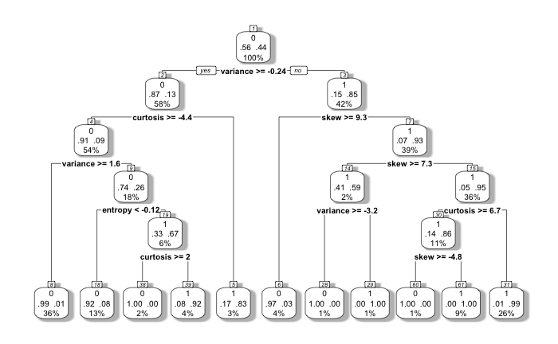

```r
prp(mod, typ = 2, extra = 104, nn = T,
    fallen.leaves = T, faclen = 4, varlen = 8, shadow.col = "gray")
```

La explicación es la siguiente:

- La función **prp** forma parte del paquete rpart.plot y se encargará de realizar la representación gráfica del árbol.
- El parámetro **type** indica los tipos de etiquetas que se representará, hay distintas formas.
- El parámetro **extra** indica la probabilidad del nodo según con respecto al nivel anterior.
- **nn** sirve para indicar número de nodo (que está indicado justo arriba de cada cuadro).
- El parámetro **fallen.leaves** sirve para indicar que todas las hojas finales se agrupen al final del gráfico (si no se indica, cada hoja final caerá donde le corresponda y no se alinearán).
- **faclen** indica el número de caracteres que debería tomar cada factor, en este caso no se aplica ya que los factores no tienen nombre.
- **varlen** indica el número de caracteres máximo que debería graficarse como nombre de cada variable (en este caso, 8 es el máximo para “variance”).
- Shadow.col, indica el color de la sombra en cada nodo.

#### Podar los árboles de clasificación

En la clase anterior, hemos visto que la se generan muchas cajas de clasificación, así que la idea es “podar” el árbol para disminuir la cantidad de información/cajas. El modelo de clasificación realizado, realmente es un modelo de componentes principales, por lo que podemos recortar el número de componentes, utilizando una regla de decisión:

```r
mod$cptable
```

```
          CP nsplit  rel error    xerror       xstd
1 0.67619048      0 1.00000000 1.0000000 0.03661106
2 0.08333333      1 0.32380952 0.3619048 0.02693302
3 0.04761905      2 0.24047619 0.2785714 0.02413533
4 0.02142857      3 0.19285714 0.2214286 0.02182179
5 0.01369048      6 0.11428571 0.1714286 0.01943149
6 0.01000000     10 0.05952381 0.1452381 0.01799597
```

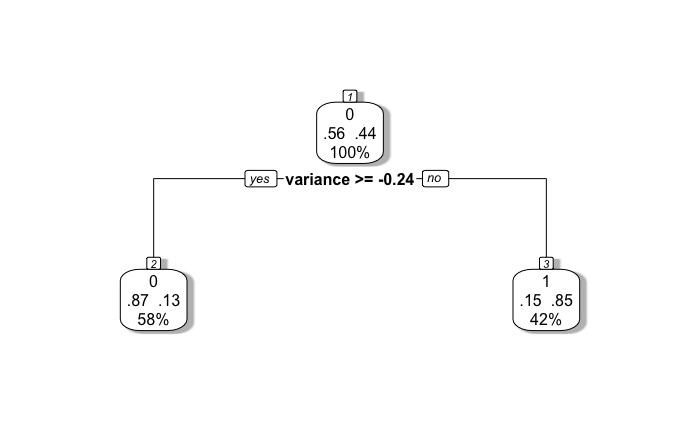

```r
mod.pruned <- prune (mod, mod$cptable[2, "CP"])
prp (mod.pruned, type = 2, extra = 104, nn = T, fallen.leaves = T, faclen = 4, varlen = 8, shadow.col = "gray")
```

Una vez que hemos generado/recortado el árbol, podríamos hacer una predicción usando el resto de datos (**RECORDEMOS QUE HICIMOS UNA PARTICIÓN DE LOS DATOS PARA OBTENER LOS DATOS PARA GENERAR EL MODELO**) y aplicando el modelo generado/recortado. Finalmente, en una matriz de confusión podríamos ver qué tanto se ajusta el modelo generado/recortado a los datos de prueba.

```r
pred.pruned1 <- predict(mod, banknote[-training.ids,], type = "class") #Genera el modelo usando los -trainings.ids usando una clasificación

confusion.matr1 <- table(banknote[-training.ids,]$class, pred.pruned1, dnn = c("Actual", "Predicho") )

confusion.matr1
```

```
      Predicho
Actual   0   1
     0 216   5
     1  23 167
```

En el caso de usar el modelo recortado:

```r
pred.pruned2 <- predict(mod.pruned, banknote[-training.ids,], type = "class") #Genera el modelo usando los -trainings.ids

confusion.matr2 <- table(banknote[-training.ids,]$class, pred.pruned2, dnn = c("Actual", "Predicho") )

confusion.matr2
```

```
      Predicho
Actual   0   1
     0 197  24
     1  47 143
```

Para generar un modelo basado en probabilidad, solo tenemos que cambiar el tipo: de **class** a **prob**

```r
pred.pruned3 <- predict(mod, banknote[-training.ids,], type = "prob")

head(pred.pruned3)
```

```
           0          1
5  0.9173554 0.08264463
11 0.9173554 0.08264463
22 0.9173554 0.08264463
32 1.0000000 0.00000000
37 0.9913793 0.00862069
41 0.9913793 0.00862069
```

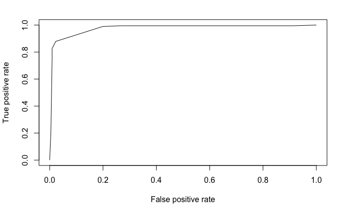

```r
library(ROCR)

#Haremos una predicción usando la segunda columna, es decir "1", lo que correspondería a "éxito" dentro del objeto pred.pruned3

pred <- prediction(pred.pruned3[,2], banknote[-training.ids, "class"])
perf <- performance (pred, "tpr", "fpr")
plot(perf)
```

```r
pred.pruned4 <- predict(mod.pruned, banknote[-training.ids,], type = "prob")

head(pred.pruned4)
```

```
           0         1
5  0.8661844 0.1338156
11 0.8661844 0.1338156
22 0.8661844 0.1338156
32 0.8661844 0.1338156
37 0.8661844 0.1338156
41 0.8661844 0.1338156
```

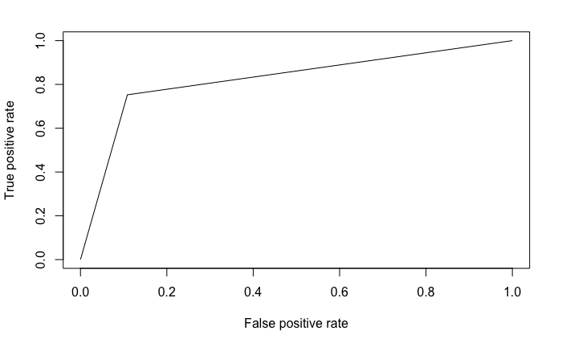

```r
library(ROCR)

#Haremos una predicción usando la segunda columna, es decir "1", lo que correspondería a "éxito" dentro del objeto pred.pruned3

pred <- prediction(pred.pruned4[,2], banknote[-training.ids, "class"])
perf <- performance (pred, "tpr", "fpr")
plot(perf)
```